# STAT 547 Homework Assignment #7

[Return to Homework 7 Folder](https://github.com/heathersummers/STAT547-hw-Summers-Heather/tree/master/hw07)

[Return to Main Page of Repository](https://github.com/heathersummers/STAT547-hw-Summers-Heather)

- Download the data
- Descriptive plots
- Perform exploratory analyses
- Perform statistical analyses
- Generate figures
- Automate the pipeline

Load the following packages:

```r
library(tidyverse)
library(broom)
library(ggplot2)
library(dplyr)
library(forcats)
```

## Download the data

```r
library(downloader)
download.file(url = "https://raw.githubusercontent.com/jennybc/gapminder/master/inst/extdata/gapminder.tsv", destfile="gapminder.tsv")
```

## Descriptive plots

Back to top

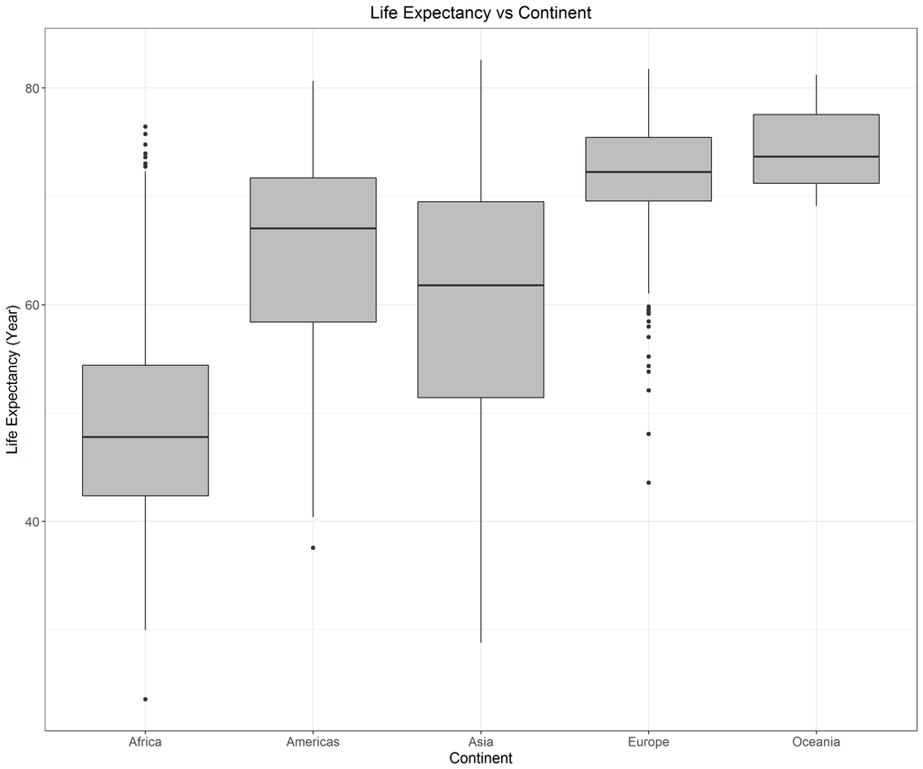

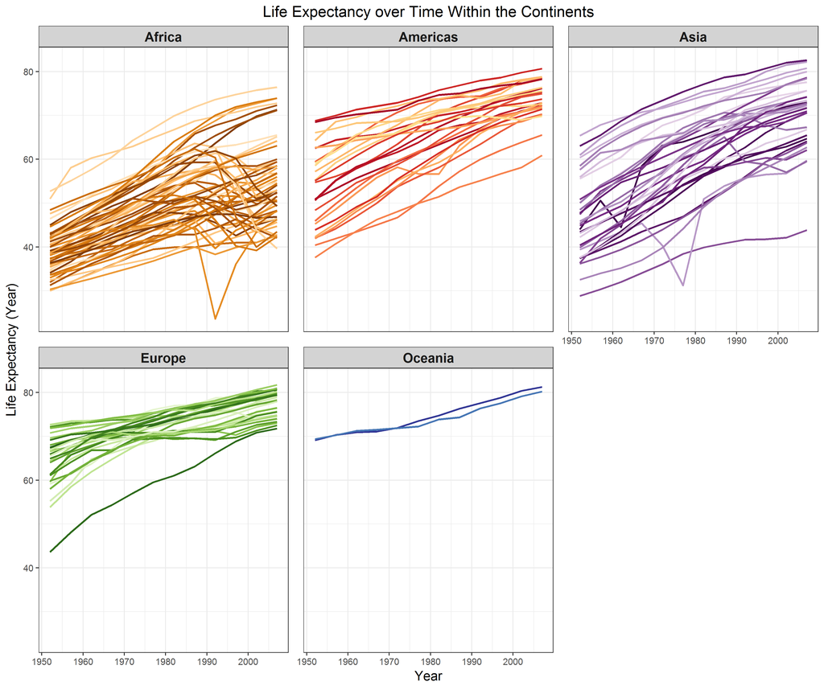

## Perform exploratory analyses

Back to top

For this section I reordered continents based on life expectancy and arranged the data on continent, country, life expectancy, year. More details regarding the code can be found [here](https://github.com/heathersummers/STAT547-hw-Summers-Heather/blob/master/hw07/gapminder_exploratory.R).

```r
gap_data <- read.delim("gapminder_clean.tsv")
(table <- head(as.data.frame(gap_data), n=10))
```

```
##    continent country lifeExp year
## 1     Africa Algeria  43.077 1952
## 2     Africa Algeria  45.685 1957
## 3     Africa Algeria  48.303 1962
## 4     Africa Algeria  51.407 1967
## 5     Africa Algeria  54.518 1972
## 6     Africa Algeria  58.014 1977
## 7     Africa Algeria  61.368 1982
## 8     Africa Algeria  65.799 1987
## 9     Africa Algeria  67.744 1992
## 10    Africa Algeria  69.152 1997
```

## Perform statistical analyses

Back to top

For this section I fit a linear regression of life expectancy on year within each country and got the estimated intercepts, slopes, and residual error variance (or sd). More details regarding the code can be found [here](https://github.com/heathersummers/STAT547-hw-Summers-Heather/blob/master/hw07/gapminder_statistical.R).

```r
coefficients_data<-read.delim("gap_coefficients.tsv")
(table <- head(as.data.frame(coefficients_data), n=10))
```

```
##    continent.x      country           term    estimate  std.error
## 1       Africa      Algeria    (Intercept) 43.37497436 0.71842024
## 2       Africa      Algeria I(year - 1952)  0.56927972 0.02212707
## 3       Africa       Angola    (Intercept) 32.12665385 0.76403549
## 4       Africa       Angola I(year - 1952)  0.20933986 0.02353200
## 5       Africa        Benin    (Intercept) 39.58851282 0.63788186
## 6       Africa        Benin I(year - 1952)  0.33423287 0.01964652
## 7       Africa     Botswana    (Intercept) 52.92911538 3.31904058
## 8       Africa     Botswana I(year - 1952)  0.06066853 0.10222519
## 9       Africa Burkina Faso    (Intercept) 34.68469231 1.11161365
## 10      Africa Burkina Faso I(year - 1952)  0.36397483 0.03423728
##     statistic      p.value continent.y       sd
## 1  60.3754908 3.776075e-14      Africa 1.323006
## 2  25.7277493 1.808143e-10      Africa 1.323006
## 3  42.0486406 1.387888e-12      Africa 1.407009
## 4   8.8959644 4.593498e-06      Africa 1.407009
## 5  62.0624528 2.868468e-14      Africa 1.174691
## 6  17.0123200 1.037138e-08      Africa 1.174691
## 7  15.9471131 1.938611e-08      Africa 6.112177
## 8   0.5934793 5.660414e-01      Africa 6.112177
## 9  31.2021109 2.684840e-11      Africa 2.047091
## 10 10.6309510 9.047506e-07      Africa 2.047091
```

I also found the four "worst" and "best" countries for each continent (except Oceania since there are not enough countries available) based on the standard error. Standard error measures the accuracy with which a sample represents a population. The smaller the standard error (i.e. smaller the spread) the higher the accuracy of the sample, the data is more representative of the true mean. The larger the standard error the less accurate the sample, the data likely has notable irregularities. More details regarding the code can be found [here](https://github.com/heathersummers/STAT547-hw-Summers-Heather/blob/master/hw07/gapminder_statistical.R).

```r
best_worst_countries<-read.delim("best_worst_countries.tsv")
(table<-as.data.frame(best_worst_countries))
```

```
##    continent.x                country           term   estimate
## 1       Africa      Equatorial Guinea I(year - 1952)  0.3101706
## 2       Africa             Mauritania I(year - 1952)  0.4464175
## 3       Africa                Comoros I(year - 1952)  0.4503909
## 4       Africa                   Mali I(year - 1952)  0.3768098
## 5       Africa               Botswana    (Intercept) 52.9291154
## 6       Africa                 Rwanda    (Intercept) 42.7419487
## 7       Africa              Swaziland    (Intercept) 46.3878590
## 8       Africa               Zimbabwe    (Intercept) 55.2212436
## 9         Asia                 Israel I(year - 1952)  0.2671063
## 10        Asia               Pakistan I(year - 1952)  0.4057923
## 11        Asia              Indonesia I(year - 1952)  0.6346413
## 12        Asia                   Iran I(year - 1952)  0.4966399
## 13        Asia                  China    (Intercept) 47.1904815
## 14        Asia       Korea, Dem. Rep.    (Intercept) 54.9056026
```

[output cut: 59 more lines]

## Generate figures

Back to top

For each continent I created a life expectancy vs. year for the two best countries (i.e. smallest std.error) and two worst countries (i.e. largest std.error).

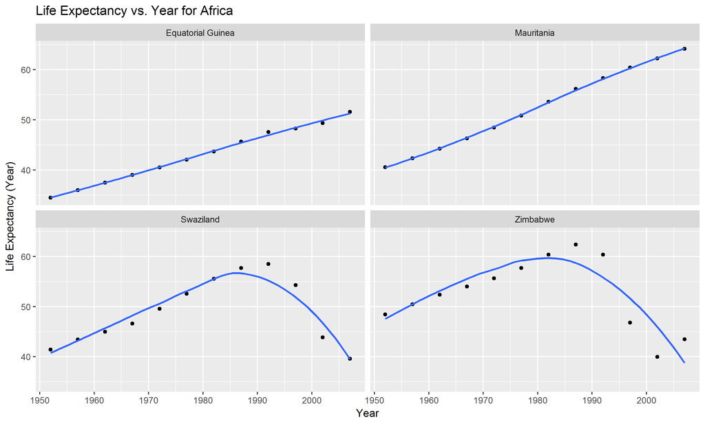

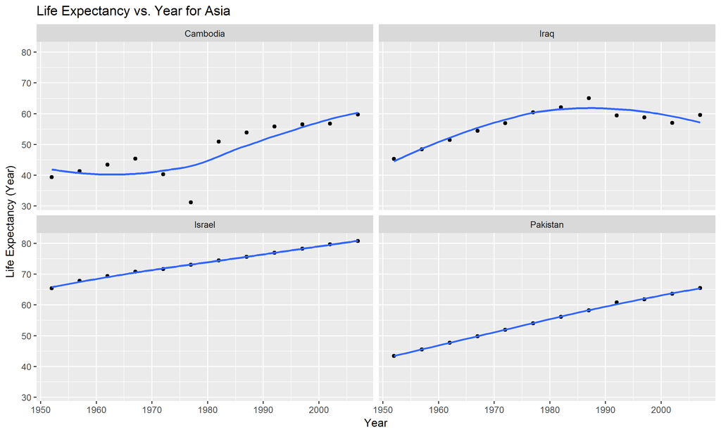

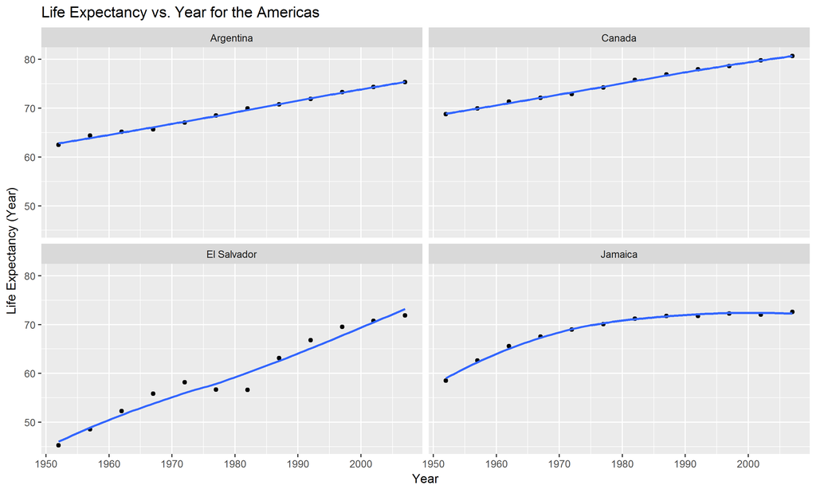

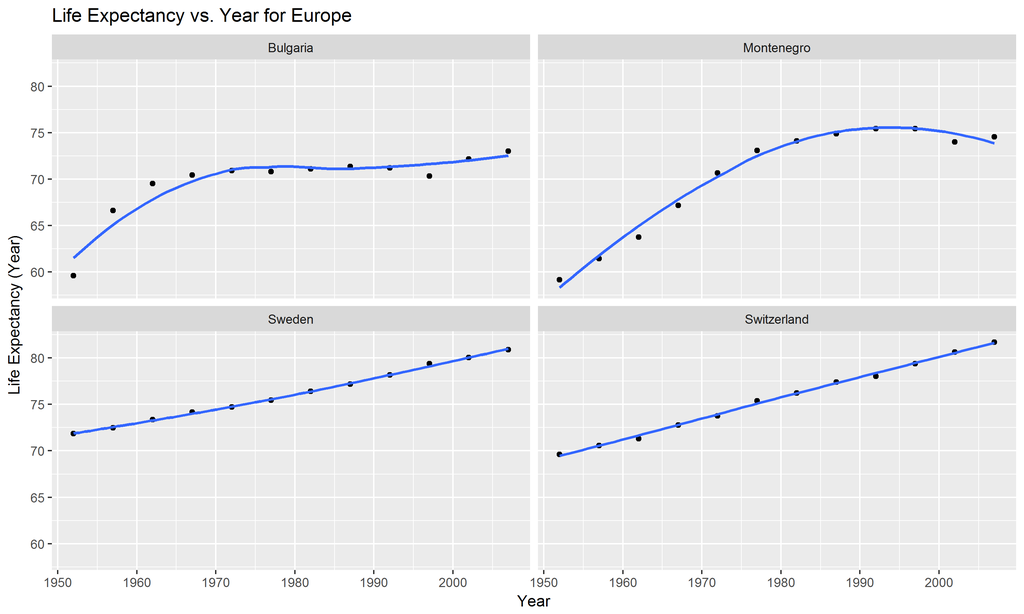

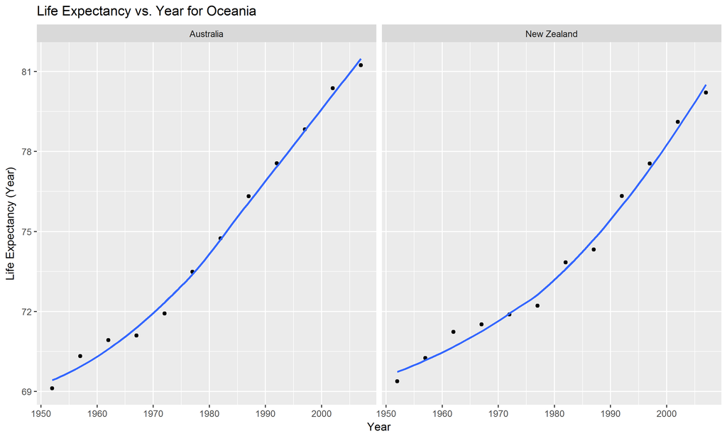

## Automate the pipeline

Back to top

I wrote a [Makefile](https://github.com/heathersummers/STAT547-hw-Summers-Heather/blob/master/hw07/Makefile.R) to automate my pipeline using R.